# Who’s the Victim in a US-China Trade War?

## Meanwhile, U.S. industries also take a hit

U.S. consumers aren’t the only ones experiencing preliminarily negative consequences from the trade war. Producers in the United States now pay higher costs for raw materials, particuarly steel, some of which they are unable or unwilling to pass on to consumers. But in addition to this, Chinese tariffs on their exports are likely to take their toll. China is still the largest importer of U.S. goods, and as a result of the trade war several large categories of exports have had 25 percent tariffs levied against them. Those goods most impacted come from rural and old industrial communities, often the most sensitive to price shifts when it comes to laying off workers and outsourcing labor.

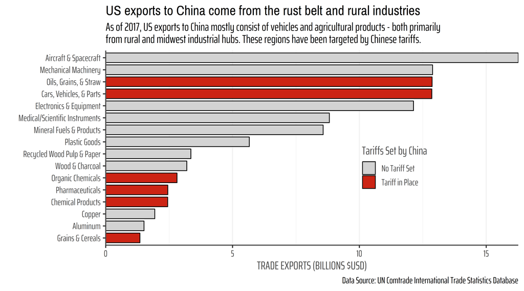

```r
# Plot comparative trade in commodity groups nationally
ggplot(com_fam_ex, aes(`Commodity`, `Trade Value`)) +
  geom_col(aes(fill = tariff), color = 'black', width = 0.8) +
  coord_flip() +
  theme(panel.grid.major.y = element_blank(), panel.grid.minor.y = element_blank(),
        legend.position = c(.7, .40)) +
  scale_y_continuous(labels = comma, breaks = seq(0, 15, 5), expand = c(0,0)) +
  scale_fill_manual("Tariffs Set by China", values = c('light grey', '#CC2414')) +
  labs(x = '', y = 'TRADE EXPORTS (BILLIONS $USD)',
       title = 'US exports to China come from the rust belt and rural industries',
       subtitle = 'As of 2017, US exports to China mostly consist of vehicles and agricultural products - both primarily \nfrom rural and midwest industrial hubs. These regions have been targeted by Chinese tariffs.',
       caption = 'Data Source: UN Comtrade International Trade Statistics Database')
```

An analysis of exports by county finds that industry relying on Chinese markets is much more dispersed than one might first believe. While there exist hubs in Washington state, California, and New York, there are also large export areas in Texas, Georgia, Tennessee, and the Rust Belt states. This suggests tariffs levied will impact producers in several states adversly, even as they benefit from higher consumer prices.

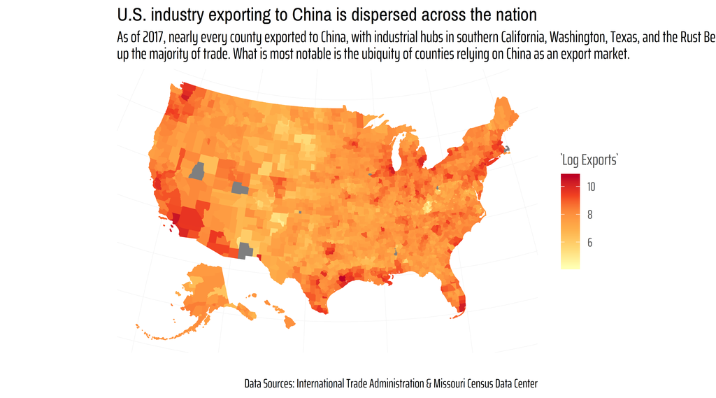

```r
library(maps)
library(mapdata)
library(rgdal)
library(rgeos)
library(zipcode)
library(albersusa)
library(plyr)

# Extract zipcode specific data
data(zipcode)
zipcode$ZIP3 <- substr(zipcode$zip, 1, 3)
zipcode$ZIP3 <- as.numeric(zipcode$ZIP3)

# Source: http://tse.export.gov/metro/SelectReports.aspx?DATA=Metro
# International Trade Administration, Department of Commerce
exp <- read_csv('2017_exports_zip.csv')
exp$ZIP3 <- as.numeric(exp$ZIP3)
exp$`Full Year` <- ifelse(exp$`Full Year` == 'D', 0, exp$`Full Year`)

zip <- merge(zipcode, exp, by = 'ZIP3')
zip$`Full Year` <- as.numeric(zip$`Full Year`)
zip$zip <- as.numeric(zip$zip)

div.zip <- zip
div.zip$cnt <- 1
div.zip <- ddply(div.zip, .(ZIP3), summarize, div = sum(cnt))

# Join zip3-specific data to each zip, creating div variable
zip <- left_join(zip, div.zip, by = 'ZIP3')

# Source: http://mcdc.missouri.edu/applications/geocorr2014.html
# Missouri Census Data Center
geo <- read_csv('geocorr2014.csv')
geo$zip <- as.numeric(as.character(geo$zcta5))

# Collect population data to weight zip breakdown by
df.zip <- merge(zip, geo, by = 'zip')
df.zip$pop10 <- as.numeric(df.zip$pop10)
df.zip$afact <- as.numeric(df.zip$afact)
df.zip$`Full Year` <- as.numeric(df.zip$`Full Year`)
df.zip <- ddply(df.zip, .(county), summarize, pop = sum(pop10*afact), exports = sum(`Full Year`*afact/div))

cty_sf <- counties_sf("aeqd")
cty_sf$county <- cty_sf$fips

# Join and accumulate by county level
data.zip <- left_join(cty_sf, df.zip, by = "county")
data.zip$`Log Exports` <- as.numeric(log10(data.zip$exports))
data.zip$`Log Exports` <- ifelse(data.zip$`Log Exports`< 0, NA, data.zip$`Log Exports`)

ggplot(data.zip, aes(fill = `Log Exports`, color = `Log Exports`)) +
  geom_sf() +
  scale_fill_distiller(palette = 'YlOrRd', direction = 1) +
  scale_color_distiller(palette = 'YlOrRd', direction = 1) +
  theme(
    axis.ticks = element_line(color = NA),
    axis.line = element_line(color = NA),
    axis.text = element_text(color = NA)) +
  labs(title = 'U.S. industry exporting to China is dispersed across the nation',
       subtitle = 'As of 2017, nearly every county exported to China, with industrial hubs in southern California, Washington, Texas, and the Rust Belt making \nup the majority of trade. What is most notable is the ubiquity of counties relying on China as an export market.',
       caption = 'Data Sources: International Trade Administration & Missouri Census Data Center')
```